# A-B-Testing

## Problem Statement

Let’s say there is an e-commerce company XYZ. It wants to make some changes in its newsletter format to increase the traffic on its website. It takes the original newsletter and marks it A and makes some changes in the language of A and calls it B. Both newsletters are otherwise the same in color, headlines, and format.

### Objective

Our objective here is to check which newsletter brings higher traffic on the website i.e the conversion rate. We will use A/B testing and collect data to analyze which newsletter performs better.

## Significance Test

Implement the Significance Test in Python Let’s see a python implementation of the significance test. Here, we have a dummy data having an experiment result of an A/B testing for 30 days. Now we will run a two-sample t-test on the data using Python to ensure the statistical significance of data.

```python
import pandas as pd
import numpy as np
import seaborn as sns
import scipy.stats as ss

import warnings
warnings.filterwarnings('ignore')

ab_df= pd.read_csv("ab-test.csv")
ab_df.head(10)
```

|  | Day | Conversion_A | Conversion_B |
| --- | --- | --- | --- |
| 0 | 1 | 0.15 | 0.19 |
| 1 | 2 | 0.12 | 0.20 |
| 2 | 3 | 0.18 | 0.18 |
| 3 | 4 | 0.19 | 0.22 |
| 4 | 5 | 0.17 | 0.19 |
| 5 | 6 | 0.13 | 0.17 |
| 6 | 7 | 0.14 | 0.18 |
| 7 | 8 | 0.23 | 0.20 |
| 8 | 9 | 0.11 | 0.17 |
| 9 | 10 | 0.15 | 0.22 |

### Data Exploration

Let’s plot the distribution of target and control group:

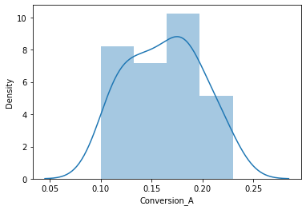

```python
sns.distplot(ab_df.Conversion_A)
```

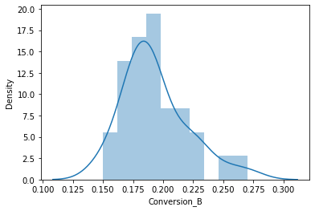

```python
sns.distplot(ab_df.Conversion_B)
```

At last, we will perform the t-test:

```python
t_stat, p_val= ss.ttest_ind(ab_df.Conversion_B,ab_df.Conversion_A)
t_stat , p_val
```

```
(3.78736793091929, 0.000363796012828762)
```

To understand this, we must be familiar with a few terms:

1. Significance level (alpha): The significance level, also denoted as alpha or α, is the probability of rejecting the null hypothesis when it is true. Generally, we use the significance value of 0.05
2. P-Value: It is the probability that the difference between the two values is just because of random chance. P-value is evidence against the null hypothesis. The smaller the p-value stronger the chances to reject the H0. For the significance level of 0.05, if the p-value is lesser than it hence we can reject the null hypothesis
3. Confidence interval: The confidence interval is an observed range in which a given percentage of test outcomes fall. We manually select our desired confidence level at the beginning of our test. Generally, we take a 95% confidence interval

#### SO what does all this mean for our A/B Testing?

Here, our p-value is less than the significance level i.e 0.05. Hence, we can reject the null hypothesis. This means that in our A/B testing, newsletter B is performing better than newsletter A. So our recommendation would be to replace our current newsletter with B to bring more traffic on our website.